# 奥肯定律在中国的适用性检验：基于失业率与GDP的时间序列分析

狗熊会

2025-03-04

# 案例背景

经济增长、充分就业是宏观经济的两大重要目标

# 学习目标

1. 时间序列数据的处理与可视化。
2. 使用ACF图和PACF图、ADF单位根检验两种方法进行平稳性检验。
3. ARIMA模型的建立与模型检验。
4. 使用OLS对奥肯定律进行初步检验。
5. 使用Engle-Granger协整分析法，构建协整模型与误差修正模型，找寻奥肯定律是否在中国成立的证据。对两变量进行Granger因果检验。

# 准备工作

```r
## 清除工作环境
cat("\014");rm(list=ls())
```

```r
## 加载程序包
library(tseries)
library(aTSA)
library(forecast)
library(lmtest)
```

# 任务一

### 数据读入

请阅读readme.txt了解各个数据表的含义以及数据中包含的变量信息。本案例研究经济增长与失业之间的关系，所以请分别读入GDP与失业率数据，即gdp.csv和unemployment.csv两个数据表。然后使用ts()将数据转换为时间序列格式。为方便分析，将GDP进行对数处理。

```r
#使用read.csv()读取csv文件中的数据
UR<-read.csv("unemployment.csv") #读入失业率数据
GDP<-read.csv("gdp.csv") 　　　　#读入GDP数据

#对读入的数据进行处理
ur<-ts(UR$ur,start=1978)  　#将失业率数据转换为时间序列
ur<-ur*100
gdp<-ts(GDP$gdp,start=1978) #将GDP数据转换为时间序列
lngdp<-log(gdp) 　　　　　　#GDP取对数
```

### 绘制时序图

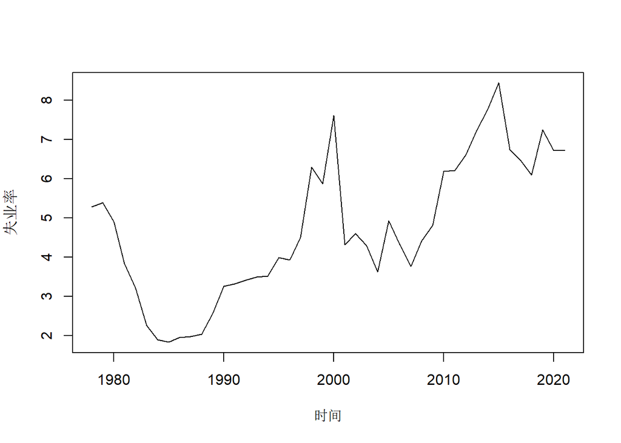

```r
#绘制失业率与对数GDP的时序图
plot(ur,xlab='时间',ylab='失业率')     #失业率时序图
```

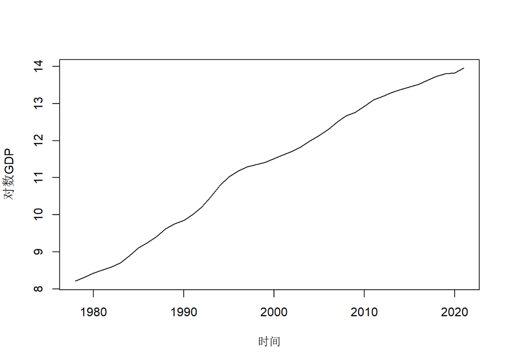

```r
plot(lngdp,xlab='时间',ylab='对数GDP') #对数GDP时序图
```

# 任务二

平稳性检验。平稳性是时间序列的一个重要属性，在时序分析中，往往会将序列平稳性作为分析的前提。本案例中，分别使用ACF图和PACF图、ADF单位根检验两种方法进行平稳性检验。

### ACF和PACF图方法

使用acf()和pacf()绘制两个序列的自相关图和部分自相关图。失业率和对数GDP序列的自相关系数衰减缓慢，且在延迟30阶后依然显著非零，说明两个序列均具有长期相关性。此外，失业率在延迟1-10期、对数GDP在延迟１－15期，其自相关系数一直为正，而后又一直为负，呈现出三角对称性，根据这样的倒三角特征可以判断两序列非平稳且具有长期趋势。

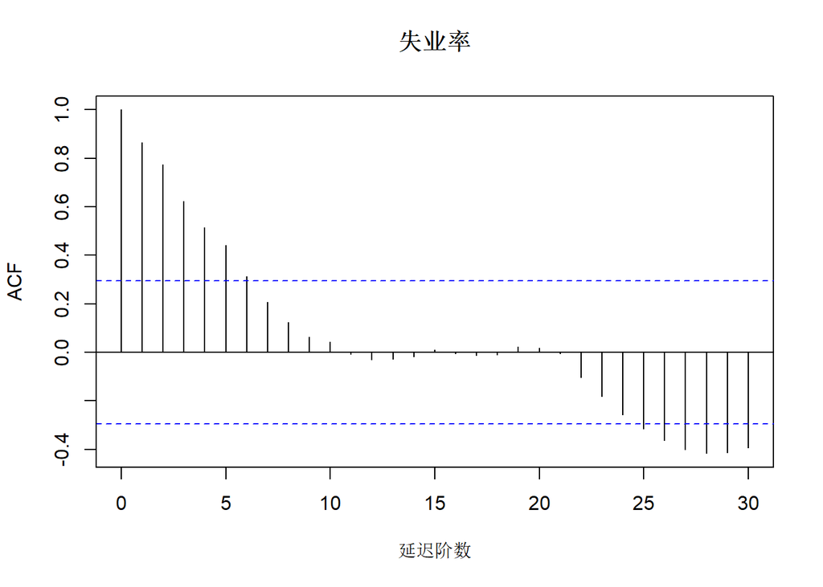

```r
#绘制ACF和PACF图
par(mfrow=c(1,1))

acf(ur,lag.max=30,main='失业率',xlab='延迟阶数')　　　#失业率的ACF图
```

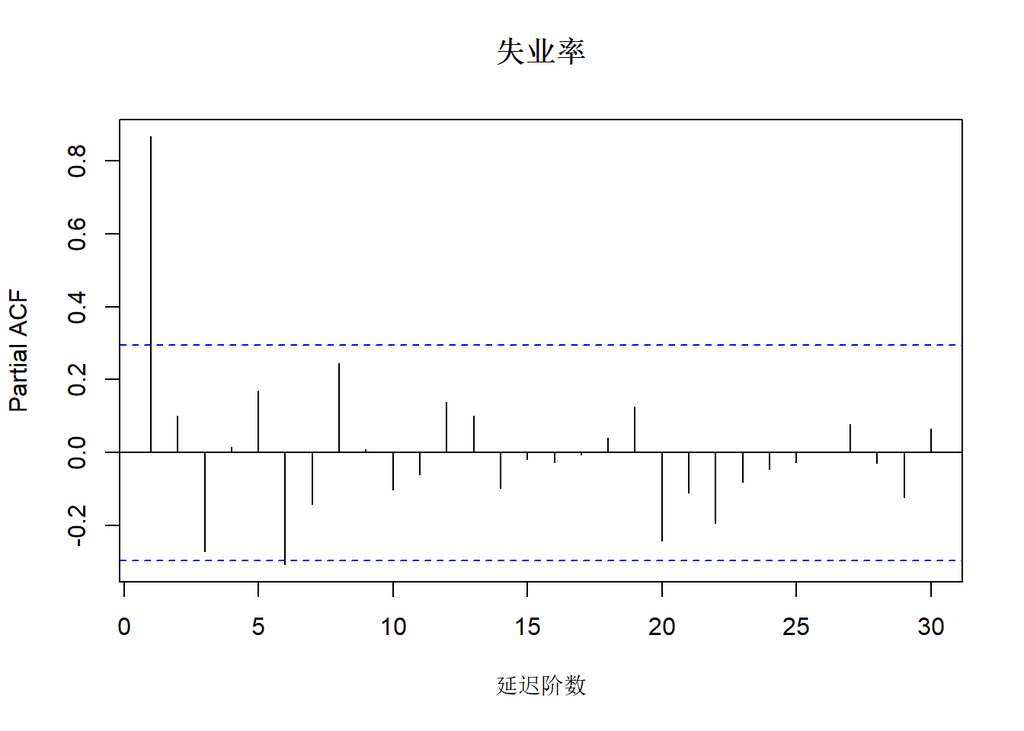

```r
pacf(ur,lag.max=30,main='失业率',xlab='延迟阶数') 　　#失业率的PACF图
```

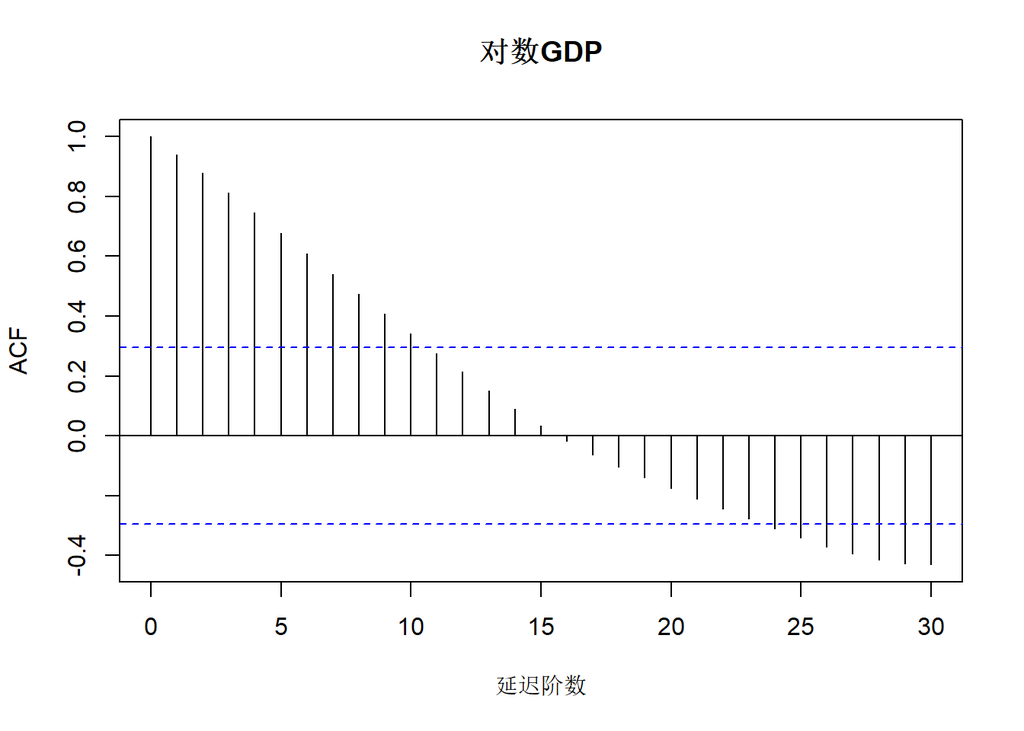

```r
acf(lngdp,lag.max=30,main='对数GDP',xlab='延迟阶数')  #对数GDP的ACF图
```

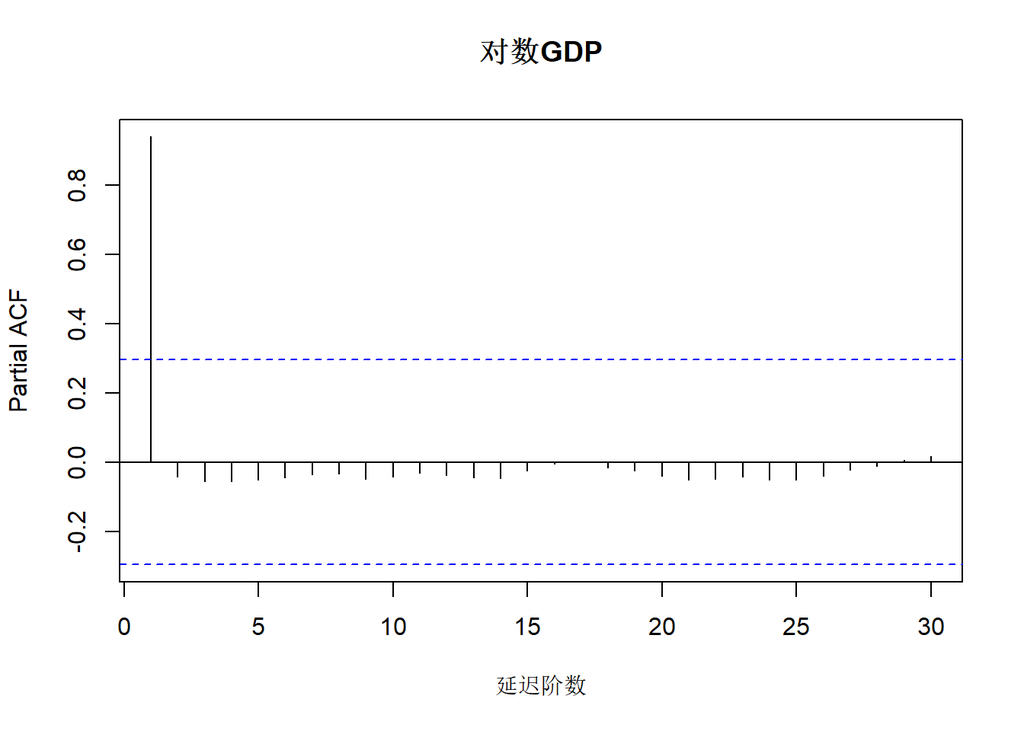

```r
pacf(lngdp,lag.max=30,main='对数GDP',xlab='延迟阶数') #对数GDP的PACF图
```

### ADF单位根检验

请分别对两序列及其一阶差分序列进行ADF单位根检验（本案例使用aTSA包中的adf.test()函数），探究其平稳性。

ADF检验结果显示，失业率和对数GDP都是非平稳序列，而经过一阶差分后，均变为平稳时间序列，这表明两个序列都是一阶单整序列I(1)。

```r
#单位根检验
dur<-diff(ur)       #对失业率序列作一阶差分
dlngdp<-diff(lngdp) #对对数GDP序列作一阶差分

aTSA::adf.test(ur)     #失业率单位根检验
```

```
## Augmented Dickey-Fuller Test
## alternative: stationary
##
## Type 1: no drift no trend
##      lag     ADF p.value
## [1,]   0 -0.2705   0.561
## [2,]   1 -0.1317   0.601
## [3,]   2 -0.2464   0.568
## [4,]   3 -0.0167   0.634
## Type 2: with drift no trend
##      lag   ADF p.value
## [1,]   0 -1.44   0.538
## [2,]   1 -1.13   0.644
## [3,]   2 -1.52   0.509
## [4,]   3 -1.48   0.524
## Type 3: with drift and trend
##      lag   ADF p.value
## [1,]   0 -3.07  0.1471
## [2,]   1 -3.15  0.1189
## [3,]   2 -3.79  0.0292
## [4,]   3 -3.66  0.0396
## ----
## Note: in fact, p.value = 0.01 means p.value <= 0.01
```

```r
aTSA::adf.test(dur)    #失业率一阶差分单位根检验
```

```
## Augmented Dickey-Fuller Test
## alternative: stationary
##
## Type 1: no drift no trend
##      lag   ADF p.value
## [1,]   0 -7.71    0.01
## [2,]   1 -3.90    0.01
## [3,]   2 -3.40    0.01
## [4,]   3 -3.88    0.01
## Type 2: with drift no trend
##      lag   ADF p.value
## [1,]   0 -7.63  0.0100
## [2,]   1 -3.87  0.0100
## [3,]   2 -3.39  0.0198
## [4,]   3 -3.90  0.0100
## Type 3: with drift and trend
##      lag   ADF p.value
## [1,]   0 -7.69  0.0100
## [2,]   1 -3.88  0.0239
## [3,]   2 -3.32  0.0823
## [4,]   3 -3.80  0.0286
## ----
## Note: in fact, p.value = 0.01 means p.value <= 0.01
```

```r
aTSA::adf.test(lngdp)  #对数GDP单位根检验
```

```
## Augmented Dickey-Fuller Test
## alternative: stationary
##
## Type 1: no drift no trend
##      lag   ADF p.value
## [1,]   0 12.20   0.990
## [2,]   1  2.01   0.987
## [3,]   2  2.48   0.990
## [4,]   3  1.59   0.969
## Type 2: with drift no trend
##      lag   ADF p.value
## [1,]   0 -1.99   0.332
## [2,]   1 -1.30   0.584
## [3,]   2 -1.42   0.543
## [4,]   3 -1.82   0.396
## Type 3: with drift and trend
##      lag    ADF p.value
## [1,]   0  0.275   0.990
## [2,]   1 -1.857   0.622
## [3,]   2 -1.151   0.904
## [4,]   3 -1.767   0.658
## ----
## Note: in fact, p.value = 0.01 means p.value <= 0.01
```

```r
aTSA::adf.test(dlngdp) #对数GDP一阶差分单位根检验
```

```
## Augmented Dickey-Fuller Test
## alternative: stationary
##
## Type 1: no drift no trend
##      lag    ADF p.value
## [1,]   0 -1.040   0.302
## [2,]   1 -1.109   0.277
## [3,]   2 -0.632   0.447
## [4,]   3 -0.813   0.383
## Type 2: with drift no trend
##      lag   ADF p.value
## [1,]   0 -2.84  0.0668
## [2,]   1 -3.46  0.0170
## [3,]   2 -2.50  0.1432
## [4,]   3 -3.38  0.0204
## Type 3: with drift and trend
##      lag   ADF p.value
## [1,]   0 -3.06  0.1550
## [2,]   1 -3.73  0.0341
## [3,]   2 -2.99  0.1812
## [4,]   3 -4.07  0.0165
## ----
## Note: in fact, p.value = 0.01 means p.value <= 0.01
```

# 任务三

ARIMA模型建立与模型检验。在研究经济增长与失业的关系之前，我们先关注两个变量各自的特征，探究其随时间的变化趋势。接下来对两个序列分别构建ARIMA(p,I,q)模型。

### 模型定阶

之前已验证失业率和对数GDP为一阶单整序列I(1)，因此模型中I取1。之后，我们通过观察一阶差分序列的自相关图与部分自相关图，来确定模型中的p和q，请使用与之前相同的方法绘制两个一阶差分序列的ACF和PACF图。

失业率的一阶差分序列ACF在1期后截尾，而PACF是拖尾的，因此选用ARIMA(0,1,1)模型对失业率进行拟合；对数GDP的一阶差分序列ACF拖尾，而PACF大约在2期后截尾，因此选用ARIMA(2,1,0)模型对对数GDP进行拟合。

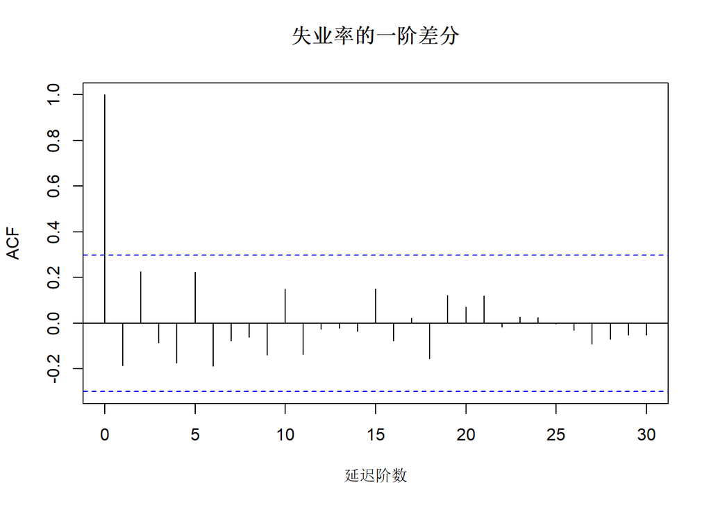

```r
#绘制差分序列ACF和PACF图
par(mfrow=c(1,1))
acf(dur,lag.max=30,main='失业率的一阶差分',xlab='延迟阶数')      #失业率一阶差分的ACF图
```

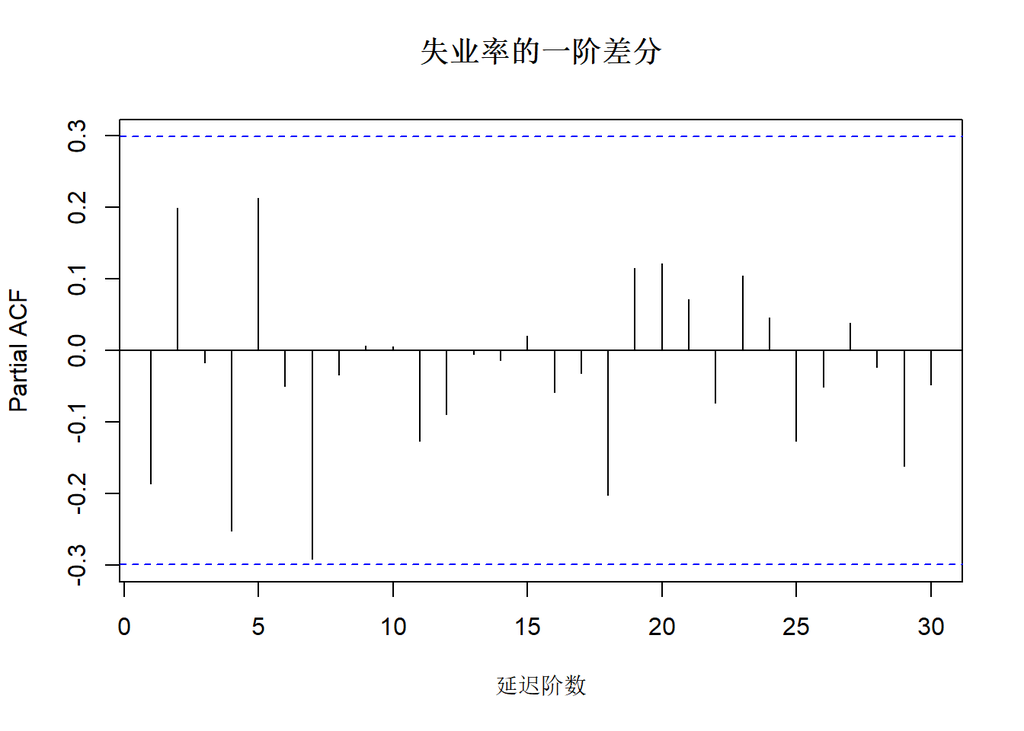

```r
pacf(dur,lag.max=30,main='失业率的一阶差分',xlab='延迟阶数')     #失业率一阶差分的PACF图
```

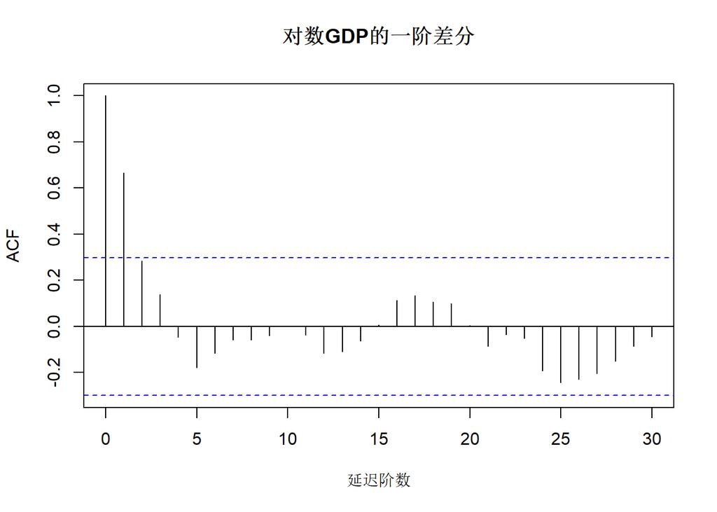

```r
acf(dlngdp,lag.max=30,main='对数GDP的一阶差分',xlab='延迟阶数')  #对数GDP一阶差分的ACF图
```

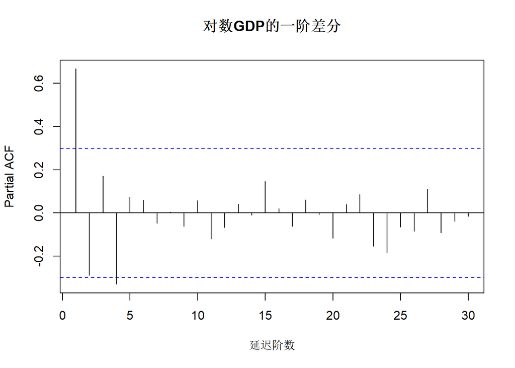

```r
pacf(dlngdp,lag.max=30,main='对数GDP的一阶差分',xlab='延迟阶数') #对数GDP一阶差分的PACF图
```

### 参数估计

由于模型拟合中涉及到一阶差分运算，我们在模型参数估计的时候选择了forecast包中的Arima函数，因为该函数修正了一些函数缺省对漂移项估计的错误。

```r
#参数估计
model_ur<-Arima(ur,order=c(0,1,1),include.drift = T)       #失业率拟合ARIMA(0,1,1)模型
model_lngdp<-Arima(lngdp,order=c(2,1,0),include.drift = T) #对数GDP拟合ARIMA(2,1,0)模型
```

### 模型检验

序列相关性问题（自相关性）在时序分析中占有特殊重要的地位，因为如果时序模型回归估计结果的残差序列具有序列相关性，那么往往暗示了模型设立存在问题，尤其是对于动态时序模型，这意味着模型估计结果很可能是无效的。因此，在完成参数估计后，有必要对模型估计结果的残差序列进行序列相关性检验。我们使用LB统计量对残差序列进行白噪声检验，用到了Box.test()函数。

各检验中，p值均大于显著性水平（α=0.05），不能拒绝原假设，因此可以认为残差序列为白噪声序列，不存在自相关性，信息已提取充分，进而之前构建的模型的合理有效的。

```r
#获取两个模型的残差
residuals_ur <- residuals(model_ur)       #失业率残差序列
residuals_lngdp <- residuals(model_lngdp) #对数GDP残差序列

#残差LB检验
for(k in 1:2){
  print(Box.test(residuals_ur,lag=6*k,type="Ljung-Box"))    #失业率残差序列LB检验
  print(Box.test(residuals_lngdp,lag=6*k,type="Ljung-Box")) #对数GDP残差序列LB检验
}
```

```
##
##  Box-Ljung test
##
## data:  residuals_ur
## X-squared = 7.3476, df = 6, p-value = 0.2899
##
##
##  Box-Ljung test
##
## data:  residuals_lngdp
## X-squared = 8.5441, df = 6, p-value = 0.2009
##
##
##  Box-Ljung test
##
## data:  residuals_ur
## X-squared = 11.581, df = 12, p-value = 0.4799
##
##
##  Box-Ljung test
##
## data:  residuals_lngdp
## X-squared = 9.9583, df = 12, p-value = 0.6196
```

# 任务四

使用OLS对奥肯定律进行初步检验。

之前的单位根检验已经验证失业率和对数GDP的一阶差分均为平稳序列，故直接根据奥肯定律差分形式（如下）进行OLS（最小二乘）回归。
$$∇u_t=a+b∇LNGDP_t+ε_t$$
回归结果显示，GDP增长率的系数为正，这意味着经济高速增长与高失业率并存，与奥肯定律相违背；而且回归系数并不显著，整个回归模型也不显著，这说明了奥肯定律的失效。

```r
ocun<-lm(dur~dlngdp)
summary(ocun)
```

```
##
## Call:
## lm(formula = dur ~ dlngdp)
##
## Residuals:
##     Min      1Q  Median      3Q     Max
## -3.3218 -0.4256 -0.0040  0.5123  1.7800
##
## Coefficients:
##             Estimate Std. Error t value Pr(>|t|)
## (Intercept) -0.01327    0.33569  -0.040    0.969
## dlngdp       0.35000    2.29534   0.152    0.880
##
## Residual standard error: 0.8959 on 41 degrees of freedom
## Multiple R-squared:  0.0005668,  Adjusted R-squared:  -0.02381
## F-statistic: 0.02325 on 1 and 41 DF,  p-value: 0.8796
```

# 任务五

使用Engle-Granger协整分析法，探索奥肯定律是否在中国成立。对于多个非平稳时间序列，有一种特殊情况，即由这几个非平稳时间序列变量的线性组合形成的变量是平稳序列。在这种情况下，我们称这些非平稳时间序列存在协整关系。Engle和Granger（1987）提出了一个简单而又容易施行的方法，通过计量检验分析非平稳序列变量之间是否具有协整关系，即检验非平稳变量之间的线性组合是否能够形成一个平稳序列，其步骤如下： - 原始模型中变量的单位根检验 - 模型的OLS回归 - 残差序列的单位根检验 - 设立并估计误差修正模型 - 诊断检验并解释实证结果

### 协整模型

首先我们建立一个回归方程，即$UR=\beta_0+\beta_1LNGDP+e_t$，并用OLS（最小二乘）方法估计出模型的残差。

接下来对残差序列进行单位根检验，判断其是否平稳。

检验结果显示，t统计量的值为-3.11，对应的p值小于0.01，因此残差序列为平稳序列，这说明GDP与失业率之间存在协整关系。

```r
#OLS估计
model<-lm(ur~lngdp)          #建立失业率和对数GDP的OLS模型
summary(model)               #模型估计结果
```

```
##
## Call:
## lm(formula = ur ~ lngdp)
##
## Residuals:
##     Min      1Q  Median      3Q     Max
## -1.8131 -0.8666 -0.3969  0.6020  2.7677
##
## Coefficients:
##             Estimate Std. Error t value Pr(>|t|)
## (Intercept)  -3.2691     1.1976  -2.730  0.00922 **
## lngdp         0.7070     0.1046   6.757 3.24e-08 ***
## ---
## Signif. codes:  0 '***' 0.001 '**' 0.01 '*' 0.05 '.' 0.1 ' ' 1
##
## Residual standard error: 1.259 on 42 degrees of freedom
## Multiple R-squared:  0.5208, Adjusted R-squared:  0.5094
## F-statistic: 45.65 on 1 and 42 DF,  p-value: 3.243e-08
```

```r
residual<-model$residuals    #取出模型残差
res<-ts(residual,start=1978) #将残差转化为时间序列

#残差单位根检验
aTSA::adf.test(res)
```

```
## Augmented Dickey-Fuller Test
## alternative: stationary
##
## Type 1: no drift no trend
##      lag   ADF p.value
## [1,]   0 -3.11    0.01
## [2,]   1 -3.05    0.01
## [3,]   2 -3.56    0.01
## [4,]   3 -3.32    0.01
## Type 2: with drift no trend
##      lag   ADF p.value
## [1,]   0 -3.08  0.0390
## [2,]   1 -3.05  0.0414
## [3,]   2 -3.59  0.0116
## [4,]   3 -3.36  0.0210
## Type 3: with drift and trend
##      lag   ADF p.value
## [1,]   0 -3.08  0.1437
## [2,]   1 -3.18  0.1070
## [3,]   2 -3.82  0.0268
## [4,]   3 -3.67  0.0389
## ----
## Note: in fact, p.value = 0.01 means p.value <= 0.01
```

### 误差修正模型

现在我们建立误差修正模型以探寻变量间的短期矫正机制。在本案例中，ECM的形式为
$$∇UR_t=\beta_0 ∇LNGDP_t+\beta_1
ECM_{t-1}+\epsilon_t$$
使用aTSA包中的ecm()函数进行参数估计。

```r
#ECM参数估计
ecm(ur,lngdp)
```

[output not shown]

结果显示，失业率的当期波动与GDP的当期波动呈现正相关，而上期误差（ECM）的系数为负，反映了ECM模型的负反馈机制。然而，对数GDP的参数估计值并不显著，整个回归方程也不显著，这表明短期内两者之间的调整机制较弱，可能存在其他因素的干扰。

### Granger因果检验

为进一步探究失业率和GDP之间是否存在某种预测关系，本案例采用Granger因果检验法，对失业率和对数GDP进行检验。首先，使用ccf()绘制互相关系数图以确定输入变量的延迟阶数。

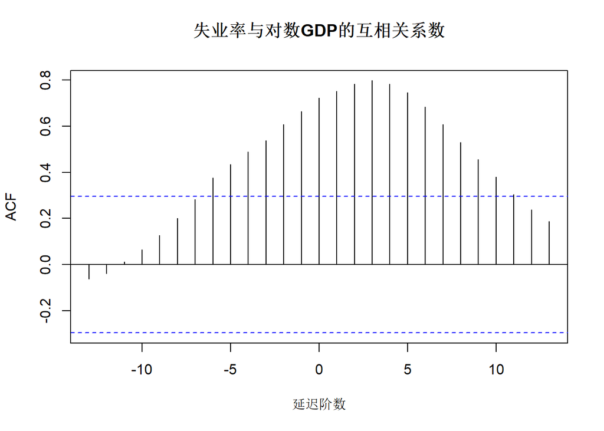

```r
#绘制互相关系数图
ccf(ur,lngdp,main='失业率与对数GDP的互相关系数',xlab='延迟阶数')
```

```r
#Granger因果检验
grangertest(ur~lngdp,order=1) #对数GDP→失业率
```

```
## Granger causality test
##
## Model 1: ur ~ Lags(ur, 1:1) + Lags(lngdp, 1:1)
## Model 2: ur ~ Lags(ur, 1:1)
##   Res.Df Df      F   Pr(>F)
## 1     40
## 2     41 -1 9.4658 0.003768 **
## ---
## Signif. codes:  0 '***' 0.001 '**' 0.01 '*' 0.05 '.' 0.1 ' ' 1
```

```r
grangertest(lngdp~ur,order=1) #失业率→对数GDP
```

```
## Granger causality test
##
## Model 1: lngdp ~ Lags(lngdp, 1:1) + Lags(ur, 1:1)
## Model 2: lngdp ~ Lags(lngdp, 1:1)
##   Res.Df Df      F    Pr(>F)
## 1     40
## 2     41 -1 15.338 0.0003418 ***
## ---
## Signif. codes:  0 '***' 0.001 '**' 0.01 '*' 0.05 '.' 0.1 ' ' 1
```